# Experiment1: NYC airline data

2023-09-06

This notebook is our first experiment in class. We will be (loosely) following the analysis from R4DS chapter 4 (https://r4ds.hadley.nz/data-transform).

# Packages

Data is from `nycflights13`. The other packages will support our analysis. I am including `here` so that we have an easy way to reference file locations.

```r
library(nycflights13)
library(tidyverse)
library(janitor)
library(here)
```

# Loading the dataset

Following from the book, we load the data, but I will save it as variable `df1`.

```r
df1=flights
```

And we briefly examine:

```r
glimpse(df1)
```

```
Rows: 336,776
Columns: 19
$ year           <int> 2013, 2013, 2013, 2013, 2013, 2013, 2013, 2013,…
$ month          <int> 1, 1, 1, 1, 1, 1, 1, 1, 1, 1, 1, 1, 1, 1, 1, 1,…
$ day            <int> 1, 1, 1, 1, 1, 1, 1, 1, 1, 1, 1, 1, 1, 1, 1, 1,…
$ dep_time       <int> 517, 533, 542, 544, 554, 554, 555, 557, 557, 55…
$ sched_dep_time <int> 515, 529, 540, 545, 600, 558, 600, 600, 600, 60…
$ dep_delay      <dbl> 2, 4, 2, -1, -6, -4, -5, -3, -3, -2, -2, -2, -2…
$ arr_time       <int> 830, 850, 923, 1004, 812, 740, 913, 709, 838, 7…
$ sched_arr_time <int> 819, 830, 850, 1022, 837, 728, 854, 723, 846, 7…
$ arr_delay      <dbl> 11, 20, 33, -18, -25, 12, 19, -14, -8, 8, -2, -…
$ carrier        <chr> "UA", "UA", "AA", "B6", "DL", "UA", "B6", "EV",…
$ flight         <int> 1545, 1714, 1141, 725, 461, 1696, 507, 5708, 79…
$ tailnum        <chr> "N14228", "N24211", "N619AA", "N804JB", "N668DN…
$ origin         <chr> "EWR", "LGA", "JFK", "JFK", "LGA", "EWR", "EWR"…
$ dest           <chr> "IAH", "IAH", "MIA", "BQN", "ATL", "ORD", "FLL"…
$ air_time       <dbl> 227, 227, 160, 183, 116, 150, 158, 53, 140, 138…
$ distance       <dbl> 1400, 1416, 1089, 1576, 762, 719, 1065, 229, 94…
$ hour           <dbl> 5, 5, 5, 5, 6, 5, 6, 6, 6, 6, 6, 6, 6, 6, 6, 5,…
$ minute         <dbl> 15, 29, 40, 45, 0, 58, 0, 0, 0, 0, 0, 0, 0, 0, …
$ time_hour      <dttm> 2013-01-01 05:00:00, 2013-01-01 05:00:00, 2013…
```

```r
head(df1)
```

| year | month | day | dep_time | sched_dep_time | dep_delay | arr_time | sched_arr_time | arr_delay | carrier | flight | tailnum | origin | dest | air_time | distance | hour | minute | time_hour |
| --- | --- | --- | --- | --- | --- | --- | --- | --- | --- | --- | --- | --- | --- | --- | --- | --- | --- | --- |
| 2013 | 1 | 1 | 517 | 515 | 2 | 830 | 819 | 11 | UA | 1545 | N14228 | EWR | IAH | 227 | 1400 | 5 | 15 | 2013-01-01 05:00:00 |
| 2013 | 1 | 1 | 533 | 529 | 4 | 850 | 830 | 20 | UA | 1714 | N24211 | LGA | IAH | 227 | 1416 | 5 | 29 | 2013-01-01 05:00:00 |
| 2013 | 1 | 1 | 542 | 540 | 2 | 923 | 850 | 33 | AA | 1141 | N619AA | JFK | MIA | 160 | 1089 | 5 | 40 | 2013-01-01 05:00:00 |
| 2013 | 1 | 1 | 544 | 545 | -1 | 1004 | 1022 | -18 | B6 | 725 | N804JB | JFK | BQN | 183 | 1576 | 5 | 45 | 2013-01-01 05:00:00 |
| 2013 | 1 | 1 | 554 | 600 | -6 | 812 | 837 | -25 | DL | 461 | N668DN | LGA | ATL | 116 | 762 | 6 | 0 | 2013-01-01 06:00:00 |
| 2013 | 1 | 1 | 554 | 558 | -4 | 740 | 728 | 12 | UA | 1696 | N39463 | EWR | ORD | 150 | 719 | 5 | 58 | 2013-01-01 05:00:00 |

# Other datasets to create

Our first tasking was to create datasets as follows: * Task 1: df2 = flights from miami in september * Task2: df3 = flights in September going to Miami * Task3: df4=flights in January going to Miami * Task4: df5=flights in summer going to Chicago

## Task 1

df2 = flights from miami in september

```r
df2=df1 |> filter(origin=="MIA",month==9)
```

It looks like this dataset only includes flights originating in New York area.

## Task 2

df3 = flights in September going to Miami

```r
df3=df1 |> filter(dest=="MIA",month==9)
```

We find 912 flights.

## Task 3

Task3: df4=flights in January going to Miami

```r
df4=df1 |> filter(dest=="MIA",month==1)
```

There are 981 January flights to Miami.

## Task4:

df5=flights in summer going to Chicago

I had to look up on line to find airports in the Chicago area.

On website https://theskydeck.com/chicago-airports/ I found:

- Chicago Midway Airport Code: MDW
- Chicago O’Hare Airport Code: ORD

For summer, I will use months June, July, and August.

```r
df5=df1 |>
  filter(dest %in%  c("MDW","ORD"),month %in% c(6,7,8))
```

Perhaps a better solution to the “in summer question” is to use the date information.

```r
df5a=df1 |>
  filter(dest %in%  c("MDW","ORD")) |>
  filter(time_hour>="2013-06-21", time_hour<="2013-09-21")
```

# Day two: class tasks

- Sometimes flight numbers are repeated. For flights to MIAMI in September, find the unique flight numbers.
- Create a dataframe df6 composed of flights to Miami with a flight number matching the smallest flight number from the set above.
- Create a visualization (using ggplot) to show the DELAYS associated with this flight number.

## Finding unique flight numbers

We start from `df3` for this question (Sep flights to Miami) and look for distinct flights, which we will sort:

```r
df_flight_num=df3 |>
  distinct(flight) |>
  arrange(flight)
```

Although there were 912 flights, there were only 57 flight numbers.

```r
head(df_flight_num)
```

| flight |
| --- |
| 83 |
| 145 |
| 172 |
| 446 |
| 476 |
| 577 |

## Flight 83 to Miami

Create a dataframe df6 composed of flights to Miami with a flight number matching the smallest flight number from the set above.

```r
df6=df1 %>% filter(flight==83,dest=="MIA")
```

## Visualization of delays for flight 83

Create a visualization (using ggplot) to show the DELAYS associated with this flight number.

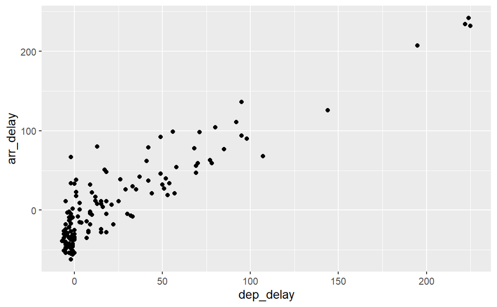

```r
df6 |>
  ggplot(aes(x=dep_delay,y=arr_delay)) +geom_point()
```